# Práctica 15 y 16: Visualización de datos con ggplot2

# 4 Gráfico 3 — Confianza pública vs. privada por voto

Dispersión de `confpub` frente a `confpriv`, distinguida por comportamiento electoral, con recta de regresión por subgrupo y una recta general para el total. Se aplica un tema personalizado.

[figure not shown]

```r
g3 <- ggplot(filter(d, urnas16r != "NC"),
             aes(x = confpub, y = confpriv, col = urnas16r)) +
  geom_point(position = position_jitter(.1), alpha = .3, shape = 1) +
  stat_smooth(method = "lm") +
  stat_smooth(method = "lm", aes(col = factor(1))) +
  scale_colour_manual(values = c("red", "black", "skyblue"),
                      labels = c("Total", "No votó", "Votó")) +
  labs(x = "Confianza instituciones privadas",
       y = "Confianza en instituciones públicas",
       col = "Elecciones 2016",
       title = "G3. Confianza en instituciones públicas y privadas") +
  theme(legend.position = "bottom",
        legend.title    = element_blank(),
        panel.grid      = element_blank(),
        axis.text       = element_text(colour = "gray"),
        axis.title      = element_text(colour = "gray"),
        axis.line       = element_line(colour = "gray"),
        axis.ticks      = element_line(colour = "gray"),
        panel.background = element_rect(fill = "white"),
        plot.title       = element_text(color = "gray31"))
g3
```

# 5 Gráfico 4 — Distribuciones de confianza pública y privada

Histogramas y densidades superpuestos para comparar las distribuciones de `confpub` y `confpriv`. Probamos distintos *temas* predefinidos del paquete `ggthemes`.

```r
g4 <- ggplot(filter(d, !is.na(confpub), !is.na(confpriv))) +
  geom_histogram(aes(x = confpub,  y = ..density.., fill = "skyblue"),
                 alpha = 0.2, bins = 30) +
  geom_histogram(aes(x = confpriv, y = ..density.., fill = "red"),
                 alpha = 0.2, bins = 30) +
  geom_density(aes(x = confpub,  col = "skyblue")) +
  geom_density(aes(x = confpriv, col = "red")) +
  scale_fill_discrete(labels  = c("Privadas", "Públicas"), name = "") +
  scale_color_discrete(labels = c("Privadas", "Públicas"), name = "") +
  labs(x = "", y = "",
       title = "G4. Distribuciones de confianza en instituciones\npúblicas y privadas")
```

## 5.1 Variantes con distintos *themes*

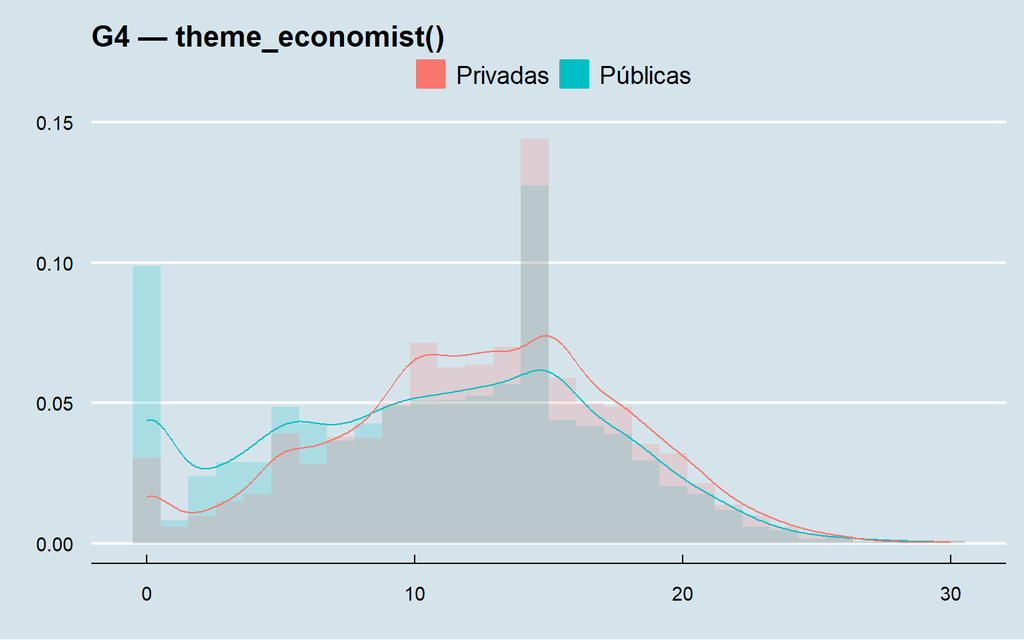

```r
g4 + theme_economist() + ggtitle("G4 — theme_economist()")
```

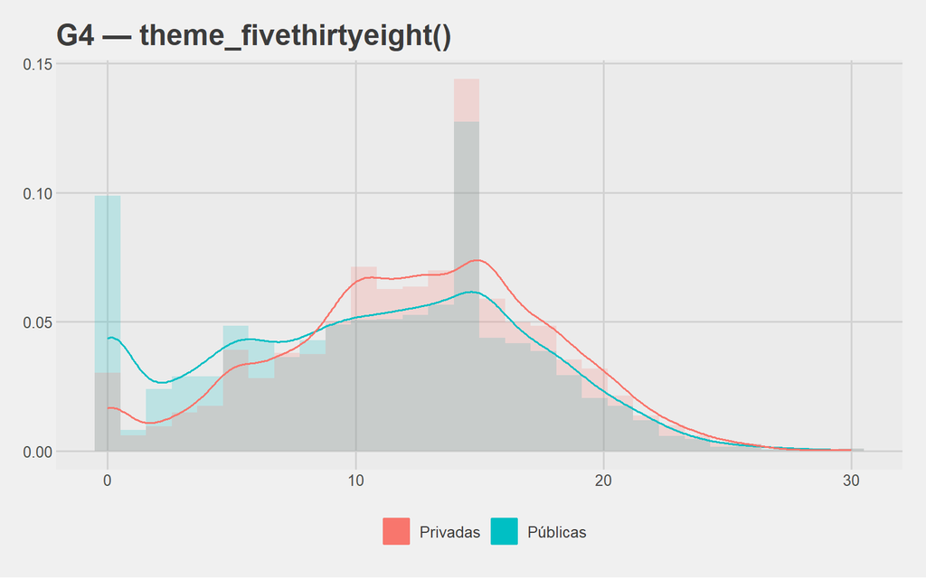

```r
g4 + theme_fivethirtyeight() + ggtitle("G4 — theme_fivethirtyeight()")
```

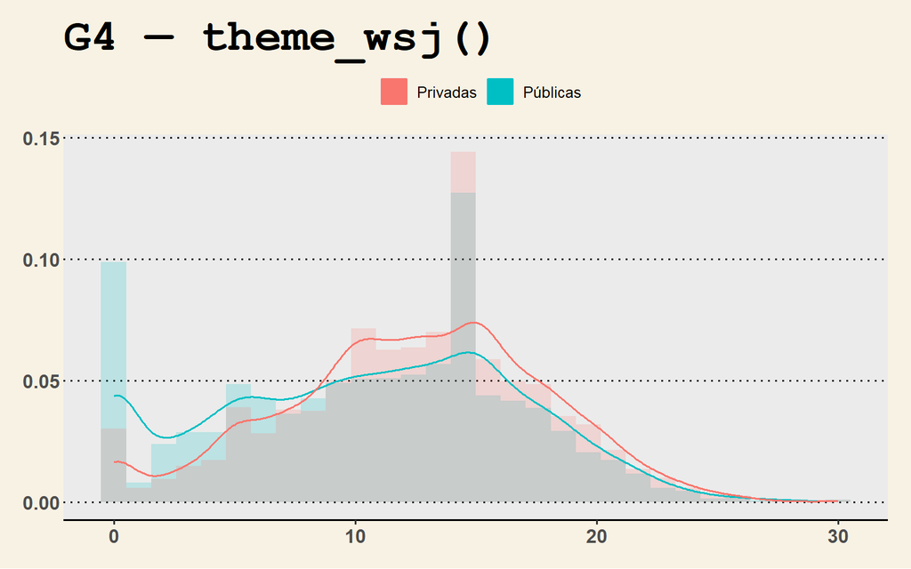

```r
g4 + theme_wsj() + ggtitle("G4 — theme_wsj()")
```

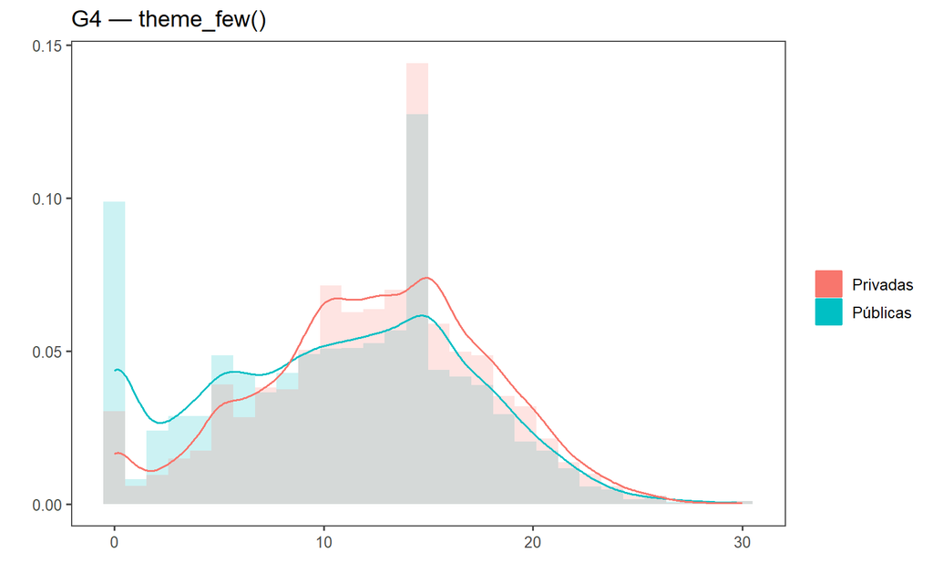

```r
g4 + theme_few() + ggtitle("G4 — theme_few()")
```

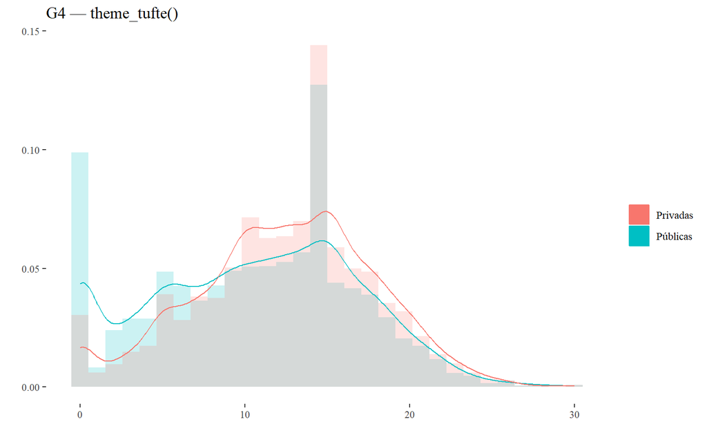

```r
g4 + theme_tufte() + ggtitle("G4 — theme_tufte()")
```

# 6 Conclusiones

- Las **facets** (G1) permiten descomponer una relación bivariada en función de una tercera variable categórica de forma muy legible.
- La elección del argumento `position` en `geom_bar()` (G2) cambia radicalmente el mensaje del gráfico; `position = "fill"` es la mejor opción cuando interesa comparar **proporciones**.
- En G3 hemos visto cómo combinar varias capas `stat_smooth()` y construir un **tema personalizado** modificando uno a uno los elementos (`element_text`, `element_line`, `element_rect`, `element_blank`).
- En G4 los **temas predefinidos** de `ggthemes` ofrecen una vía rápida para dar un acabado profesional sin tener que ajustar manualmente cada elemento.